# Evaluatie soortenmeetnetten 2018

#### 4.3.1.4 Evolutie gemiddelde aantallen per locatie en per jaar

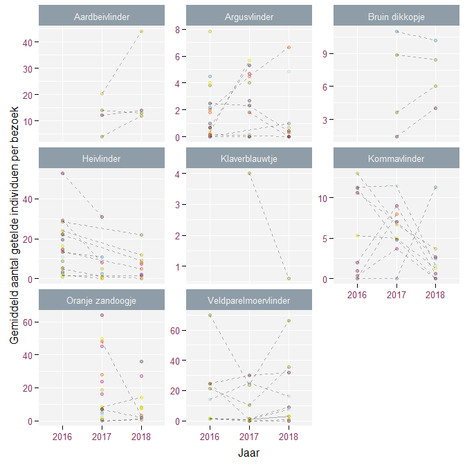

Figuur 4.4: Gemiddeld aantal getelde individuen per locatie en per jaar

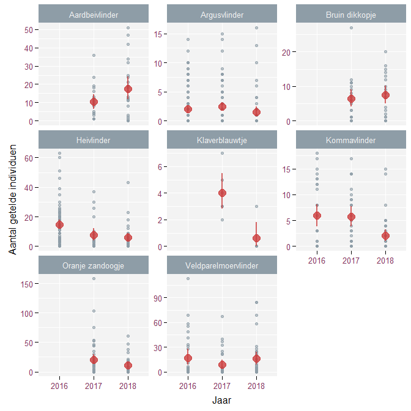

Figuur 4.5: Gemiddeld aantal getelde individuen per jaar met 95%-betrouwbaarheidsinterval (rood) en aantal getelde individuen per bezoek (grijs)

### 4.3.2 Gebiedstellingen

#### 4.3.2.1 verdeling getelde aantallen per bezoek

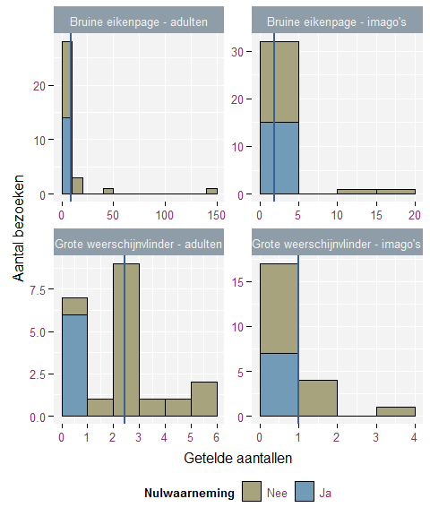

#### 4.3.2.2 Evolutie getelde aantallen binnen telperiode

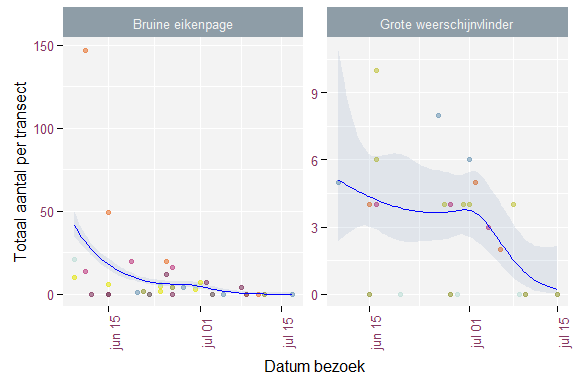

Figuur 4.7: Evolutie totaal getelde aantallen per bezoek en globale evolutie - Bruine eikenpage en Grote weerschijnvlinder

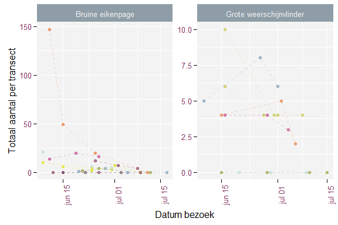

Figuur 4.8: Evloutie totaal getelde aantallen per bezoek waarbij bezoeken aan eenzelfde locatie met stippellijn worden verbonden - Bruine eikenpage en Grote weerschijnvlinder

### 4.3.3 Eitellingen

#### 4.3.3.1 verdeling getelde aantallen per bezoek

Figuur 4.9 toont de verdeling van het aantal getelde eitjes van Gentiaanblauwtje per knop. Het merendeel van de knoppen bevat geen eitjes.

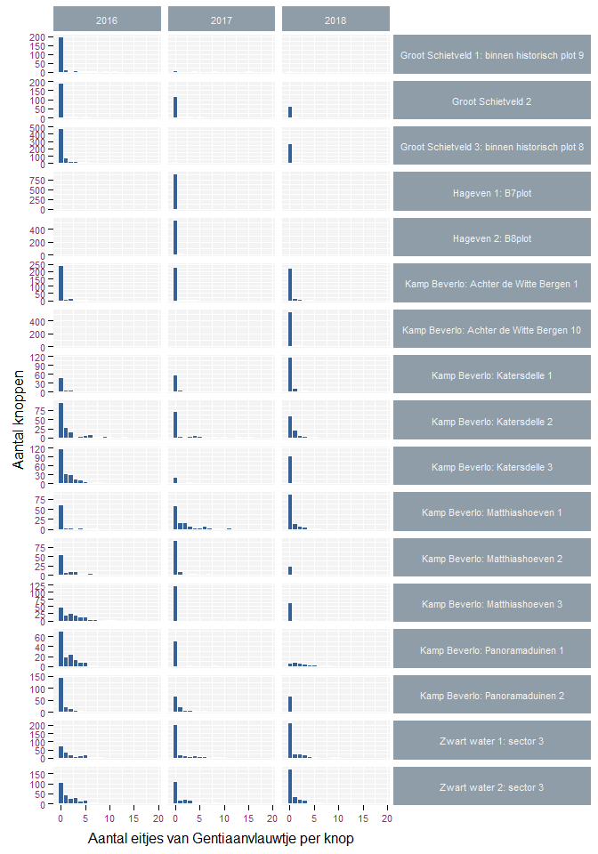

Figuur 4.9: Verdeling aantal getelde eitjes per knop

#### 4.3.3.2 Evolutie gemiddelde aantallen per locatie en per jaar

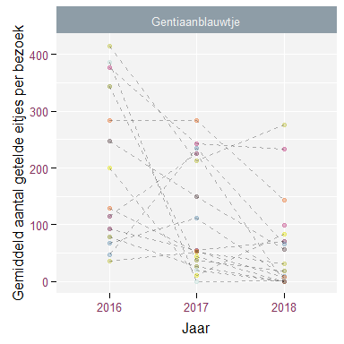

Figuur 4.10: Evolutie aantal getelde eitjes per locatie

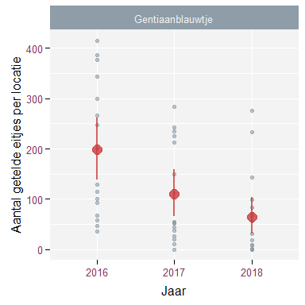

Figuur 4.11: Gemiddeld aantal getelde eitjes per jaar met 95%-betrouwbaarheidsinterval (rood) en aantal getelde eitjes per locatie (grijs)

## 4.4 Verkenning ingevoerde waarden voor de covariabelen

Hieronder geven we een overzicht van de ingevoerde waarden voor de covariabelen.

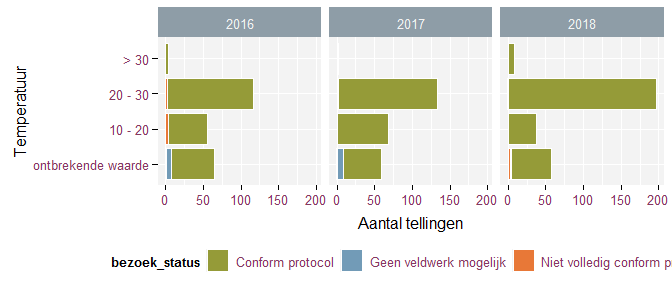

Figuur 4.12: Overzicht ingevoerde gegevens temperatuur

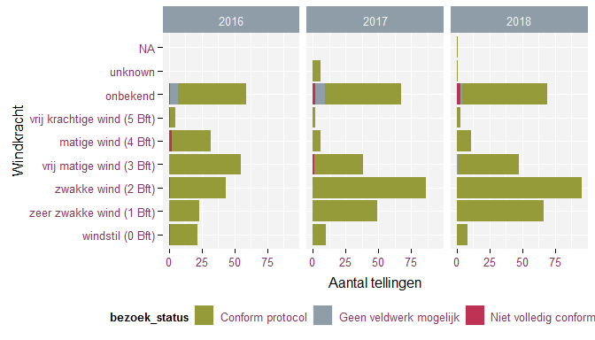

Figuur 4.13: Overzicht ingevoerde gegevens windkracht

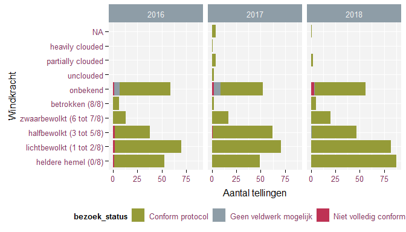

Figuur 4.14: Overzicht ingevoerde gegevens bewolking

# 5 Bijlagen

We geven per soortengroep een gedetailleerd overzicht van de uitgevoerde taken in 2018. Daarbij maken we onderscheid tussen:

- TakenCP: taken uitgevoerd conform protocol
- TakenNVCP: taken uitgevoerd niet volledig conform protocol
- TakenGVM: taak niet uitgevoerd want geen veldwerk mogelijk
- GeenInvoer: geen gegevens ingevoerd voor taak in meetnetten.be

## 5.1 Overzicht taken amfibieënmeetnetten

### 5.1.1 Kikkers en padden

#### 5.1.1.1 Boomkikker en knoflookpad

| Meetnet | Locatie | Type locatie | Bezoek status | Roepkoren telling 1 | Roepkoren telling 2 | Schepbezoek 1 | Extra telling - larven | Extra telling - roepkoren |
| --- | --- | --- | --- | --- | --- | --- | --- | --- |
| Boomkikker | Gouvernement polder | Meetnetlocatie | TellingGVM | 0 | 0 | 0 | 1 | 2 |
| Boomkikker | Kasteel De Schans | Meetnetlocatie | Geen invoer | 0 | 0 | 0 | 0 | 0 |
| Boomkikker | NR 't Hasselterbroek 5 | Meetnetlocatie | TellingCP | 0 | 0 | 0 | 1 | 2 |
| Boomkikker | NR Platwijers 1 | Meetnetlocatie | TellingCP | 1 | 1 | 1 | 0 | 0 |
| Boomkikker | NR Platwijers 2 | Meetnetlocatie | TellingCP | 1 | 1 | 1 | 0 | 0 |
| Boomkikker | NR Terlamen 1 | Meetnetlocatie | TellingCP | 1 | 1 | 1 | 0 | 0 |
| Boomkikker | NR Terlamen 2 | Meetnetlocatie | TellingCP | 1 | 1 | 1 | 0 | 0 |
| Boomkikker | NR Wijvenheide 1 | Meetnetlocatie | TellingCP | 1 | 1 | 1 | 0 | 0 |
| Boomkikker | NR Wijvenheide 2 | Meetnetlocatie | TellingCP | 1 | 1 | 1 | 0 | 0 |
| Boomkikker | NR Wijvenheide 3 | Meetnetlocatie | TellingCP | 1 | 1 | 1 | 0 | 0 |

[output cut: 34 more lines]

#### 5.1.1.2 Rugstreeppad

| Meetnet | Locatie | Bezoek status | Extra telling - roepkoren of zichtwaarneming |
| --- | --- | --- | --- |
| Rugstreeppad | Hazop | TellingCP | 9 |
| Rugstreeppad | Houtsaegerduinen | TellingCP | 2 |
| Rugstreeppad | Melselepolder | TellingCP | 2 |
| Rugstreeppad | Noordduinen | TellingCP | 2 |
| Rugstreeppad | Oosthoek | TellingCP | 2 |
| Rugstreeppad | St-Martinusberg | TellingCP | 9 |
| Rugstreeppad | Verrebroek | TellingCP | 3 |
| Rugstreeppad | Westhoek | TellingCP | 2 |
| Rugstreeppad | Zeepanne | TellingCP | 2 |

### 5.1.2 Salamanders

#### 5.1.2.1 Kamsalamander

| Meetnet | Locatie | Type locatie | Bezoek status | Fuikronde 1 | Fuikronde 2 | Schepronde 1 | Extra telling - fuiken | Extra telling - larven |
| --- | --- | --- | --- | --- | --- | --- | --- | --- |
| Kamsalamander | Antitankgracht Haacht - Poel 12 | Meetnetlocatie | TellingCP | 2 | 1 | 0 | 0 | 0 |
| Kamsalamander | Antitankgracht Haacht - Poel 15 | Meetnetlocatie | TellingCP | 2 | 1 | 0 | 0 | 0 |
| Kamsalamander | Antitankgracht Haacht - Poel 16c | Meetnetlocatie | TellingCP | 2 | 1 | 0 | 0 | 0 |
| Kamsalamander | Blauwhofstraat 1 | Meetnetlocatie | TellingCP | 0 | 0 | 0 | 3 | 1 |
| Kamsalamander | Bolderik 1 | Meetnetlocatie | TellingCP | 0 | 0 | 0 | 2 | 1 |
| Kamsalamander | Dauteweyers - Poel 11 | Meetnetlocatie | TellingCP | 1 | 1 | 1 | 0 | 0 |
| Kamsalamander | Dauteweyers - Poel 4 | Meetnetlocatie | TellingCP | 1 | 1 | 1 | 0 | 0 |
| Kamsalamander | Dauteweyers - Poel 6 | Meetnetlocatie | TellingCP | 1 | 1 | 1 | 0 | 0 |
| Kamsalamander | Dauteweyers - Poel 7 | Meetnetlocatie | TellingCP | 1 | 1 | 1 | 0 | 0 |
| Kamsalamander | De Brand - Poel 14 | Meetnetlocatie | Geen invoer | 0 | 0 | 0 | 0 | 0 |

[output cut: 54 more lines]

#### 5.1.2.2 Vuursalamander

| Meetnet | Locatie | Bezoek status | Extra telling | Transecttelling 1 | Transecttelling 2 |
| --- | --- | --- | --- | --- | --- |
| Vuursalamander | 't Burreken | TellingCP | 0 | 1 | 1 |
| Vuursalamander | Bos Terrijst | TellingCP | 1 | 1 | 1 |
| Vuursalamander | Bos Terrijst | TellingNVCP | 1 | 0 | 0 |
| Vuursalamander | Brakelbos | TellingCP | 0 | 1 | 1 |
| Vuursalamander | Broekbos | Geen invoer | 0 | 0 | 0 |
| Vuursalamander | Brouwierbos (Gerrebroekbeek) | TellingCP | 1 | 3 | 1 |
| Vuursalamander | Buggenhoutbos Doorselaer | TellingCP | 0 | 1 | 1 |
| Vuursalamander | Buggenhoutbos noord | TellingCP | 0 | 1 | 1 |
| Vuursalamander | Buggenhoutbos noord Krokkebaas | TellingCP | 0 | 1 | 1 |
| Vuursalamander | Buggenhoutbos west | TellingCP | 0 | 1 | 1 |

[output cut: 33 more lines]

## 5.2 Overzicht taken vlindermeetnetten

### 5.2.1 Transecttellingen en gebiedstellingen

| meetnet | Locatie | Bezoek status | Extra telling | Telling 1 | Telling 2 | Telling 3 | Telling 4 | Telling 5 | Telling 6 |
| --- | --- | --- | --- | --- | --- | --- | --- | --- | --- |
| Aardbeivlinder | Drongengoed | TellingCP | 0 | 1 | 1 | 1 |  |  |  |
| Aardbeivlinder | GulkePutten | TellingCP | 0 | 1 | 2 | 1 |  |  |  |
| Aardbeivlinder | Houthulstbos | TellingCP | 0 | 1 | 1 | 1 |  |  |  |
| Aardbeivlinder | KleinSchietveld | TellingCP | 2 | 6 | 3 | 2 |  |  |  |
| Argusvlinder | Arenbergpolder | TellingCP | 6 | 0 | 0 | 0 | 0 | 0 | 0 |
| Argusvlinder | Boenderberg | Geen invoer | 0 | 0 | 0 | 0 | 0 | 0 | 0 |
| Argusvlinder | Cabourg | Geen invoer | 0 | 0 | 0 | 0 | 0 | 0 | 0 |
| Argusvlinder | Eendenkooi | Geen invoer | 0 | 0 | 0 | 0 | 0 | 0 | 0 |
| Argusvlinder | Fort Liefkenshoek | TellingCP | 0 | 1 | 1 | 1 | 1 | 1 | 1 |
| Argusvlinder | Fort Napoleon | Geen invoer | 0 | 0 | 0 | 0 | 0 | 0 | 0 |

[output cut: 127 more lines]

### 5.2.2 Eitellingen

| meetnet | locatie | taak | bezoek_status | aantalTellingen |
| --- | --- | --- | --- | --- |
| Gentiaanblauwtje | Groot Schietveld 1: binnen historisch plot 9 | Extra telling | TellingCP | 1 |
| Gentiaanblauwtje | Groot Schietveld 2 | Extra telling | TellingCP | 1 |
| Gentiaanblauwtje | Groot Schietveld 3: binnen historisch plot 8 | Extra telling | TellingCP | 1 |
| Gentiaanblauwtje | Hageven 1: B7plot | Extra telling | TellingCP | 1 |
| Gentiaanblauwtje | Hageven 2: B8plot | Extra telling | TellingCP | 1 |
| Gentiaanblauwtje | Kamp Beverlo: Achter de Witte Bergen 1 | Extra telling | TellingCP | 1 |
| Gentiaanblauwtje | Kamp Beverlo: Achter de Witte Bergen 10 | Extra telling | TellingCP | 1 |
| Gentiaanblauwtje | Kamp Beverlo: Katersdelle 1 | Extra telling | TellingCP | 1 |
| Gentiaanblauwtje | Kamp Beverlo: Katersdelle 2 | Extra telling | TellingCP | 1 |
| Gentiaanblauwtje | Kamp Beverlo: Katersdelle 3 | Extra telling | TellingCP | 1 |

[output cut: 7 more lines]

## 5.3 Overzicht taken libellenmeetnetten

### 5.3.1 Transecttellingen en gebiedstellingen

| meetnet | Locatie | Bezoek status | Extra telling | Telling 1 | Telling 2 | Telling 3 |
| --- | --- | --- | --- | --- | --- | --- |
| Bosbeekjuffer | Abeek | TellingCP | 0 | 1 | 1 | 1 |
| Bosbeekjuffer | Afwateringskanaal | Geen invoer | 0 | 0 | 0 | 0 |
| Bosbeekjuffer | Altenbroek | Geen invoer | 0 | 0 | 0 | 0 |
| Bosbeekjuffer | Bosbeek noord | TellingCP | 0 | 1 | 1 | 1 |
| Bosbeekjuffer | Bosbeek zuid | TellingCP | 0 | 1 | 1 | 1 |
| Bosbeekjuffer | Daelmansloop | Geen invoer | 0 | 0 | 0 | 0 |
| Bosbeekjuffer | De Kluis - Blommerschot | Geen invoer | 0 | 0 | 0 | 0 |
| Bosbeekjuffer | De Most | Geen invoer | 0 | 0 | 0 | 0 |
| Bosbeekjuffer | Dommel | Geen invoer | 0 | 0 | 0 | 0 |
| Bosbeekjuffer | Griesbroek - Grote Nete | Geen invoer | 0 | 0 | 0 | 0 |

[output cut: 116 more lines]

### 5.3.2 Tellingen larvenhuidjes

| meetnet | Locatie | Bezoek status | Extra telling | Telling 1 | Telling 2 | Telling 3 | Telling 4 | Telling 5 | Telling 6 |
| --- | --- | --- | --- | --- | --- | --- | --- | --- | --- |
| Rivierrombout | Beringen oude kolenhaven - noord | TellingCP | 0 | 1 | 1 | 1 | 1 | 1 | 1 |
| Rivierrombout | Bouwel uitbreidingsstraat | TellingCP | 0 | 2 | 1 | 1 | 1 | 1 | 1 |
| Rivierrombout | Deurne vaartdijk - zuid | TellingCP | 0 | 1 | 1 | 1 | 1 | 1 | 1 |
| Rivierrombout | Diepenbeek Sas - zuid | TellingCP | 0 | 1 | 1 | 1 | 0 | 0 | 0 |
| Rivierrombout | Hasselt Nijverheidskaai - noord | TellingCP | 0 | 1 | 1 | 1 | 1 | 0 | 0 |
| Rivierrombout | Massenhoven brug - noord | TellingCP | 0 | 1 | 1 | 1 | 0 | 0 | 0 |
| Rivierrombout | Punt oost brug N19 - noord | TellingCP | 1 | 1 | 1 | 1 | 1 | 1 | 0 |
| Rivierrombout | Punt oost brug N19 - zuid | TellingCP | 1 | 1 | 1 | 1 | 1 | 1 | 0 |
| Rivierrombout | Ranst zwaaikom - noord | Geen invoer | 0 | 0 | 0 | 0 | 0 | 0 | 0 |
| Rivierrombout | Ranst zwaaikom - zuid | Geen invoer | 0 | 0 | 0 | 0 | 0 | 0 | 0 |

[output cut: 5 more lines]

## 5.5 Overzicht taken overige soortengroepen